# Estimating Annual Non-Hispanic Black Population Share in Cook County, IL

A TWDeConv Example: Deconvolving ACS 5-Year Estimates and Validating Against the 2020 Decennial Census

TWDeConv Example

2026-03-05

# 1 Background

The ACS 5-year estimate for the proportion of non-Hispanic (NH) Black residents in Census tract $i$ ending in year $s$ is approximately:

$$P_{i,s} = \frac{1}{5}\sum_{t=s-4}^{s}
X_{i,t} + \varepsilon_{i,s}$$

where $X_{i,t}$ is the **true annual** NH Black population share — never directly observed at the annual, tract level. **TWDeConv** recovers $X$ by solving a Kronecker-structured spatio-temporal generalised lasso via ADMM.

Because the observable $P_{i,s}$ is a **derived proportion** (not a single ACS variable), we compute it and its standard error from two ACS variables:

| Variable | Description |
| --- | --- |
| `B03002_001` | Total population |
| `B03002_004` | Not Hispanic or Latino: Black or African American alone |

$$P_{i,s} =
\frac{\hat{X}^{\text{Black}}_{i,s}}{\hat{X}^{\text{Total}}_{i,s}},
\quad
\widehat{\text{SE}}(P_{i,s}) = \frac{1}{\hat{X}^{\text{Total}}_{i,s}}
\sqrt{\widehat{\text{SE}}^2_{\text{Black}} - P_{i,s}^2\,
\widehat{\text{SE}}^2_{\text{Total}}}$$

(ACS ratio SE formula; falls back to the sum-of-squares form when the discriminant is negative.)

The recovered 2020 annual estimates are then validated against the **2020 Decennial Census** PL 94-171 redistricting file — a full enumeration with no sampling error — making this the only example in the package with near-true ground truth at the tract level.

Cook County, IL contains ~1,300 Census tracts, a substantially larger problem than the St. Louis City income example.

# 2 Setup

```r
devtools::install_github("YungChun0303/TWDeConv")
packageVersion("TWDeConv")
```

```
## [1] '0.1.1'
```

```r
library(TWDeConv)
library(ggplot2)
library(patchwork)
library(sf)
library(Matrix)

options(tigris_use_cache = TRUE)
```

> **Census API key required.** Register at https://api.census.gov/data/key_signup.html and install once with:

> ```r
> tidycensus::census_api_key("YOUR_KEY_HERE", install = TRUE)
> ```

# 3 Fetch and Prepare ACS Data

We use five consecutive ACS 5-year windows (end years 2020–2024):

- $S = 5$ observed windows
- $T = S + 4 = 9$ latent annual time points (2016–2024)

## 3.1 Step 1: Structural matrices from NH Black counts

`prep_acs_for_deconv()` is called with `B03002_004` (NH Black count) to obtain the five structural matrices ($Y$, $M$, $W$, $D$, $L_s$) and the aligned GEOID set. We will replace $Y$ and $W$ with proportion-based counterparts in Step 2.

```r
year_ends <- 2020:2024
S         <- length(year_ends)

inp_black <- prep_acs_for_deconv(
  state     = "IL",
  county    = "Cook",
  year_ends = year_ends,
  variables = c(black_nh = "B03002_004"),
  k         = 2L,
  queen     = TRUE,
  vre       = TRUE,
  cache_dir = "~/acs_cache"
)
print(inp_black)
```

```
## ── DeconvInput (TWDeConv) ─────────────────────────────────
##   Geography : tract  |  Cook county, IL
##   Variable  : black_nh  (code: B03002_004)
##   Windows   : 5  (ACS end years 2020 – 2024)
##   Latent yrs: 9  (2016 – 2024)
##   Units (n) : 1332
##   Y dims    : 1332 × 5  (units × windows)
##   M dims    : 5 × 9  (windows × latent years)
##   W dims    : 6660 × 6660  (diagonal precision)
##   D dims    : 7 × 9  (order-2 temporal diff)
##   Ls dims   : 1332 × 1332  (spatial Laplacian)
##   SE source : moe
##
##   Pass to solver:
##     solver <- ADMMSolver$new(
##       Y=inp$Y, M=inp$M, W=inp$W, D=inp$D, Ls=inp$Ls,
##       lambda_t=..., lambda_s=..., rho=1, ridge=1e-4
##     )
## ────────────────────────────────────────────────────────────
```

```r
common_geoids <- rownames(inp_black$Y)
n_tracts      <- length(common_geoids)
cat("Common tracts across all windows:", n_tracts, "\n")
```

```
## Common tracts across all windows: 1332
```

## 3.2 Step 2: Fetch total population (denominator)

```r
total_list <- vector("list", S)
for (i in seq_len(S)) {
  total_list[[i]] <- fetch_acs_vre_data(
    state     = "IL",
    county    = "Cook",
    year_end  = year_ends[i],
    variables = c(total = "B03002_001"),
    geometry  = FALSE,
    vre       = FALSE,          # VRE not needed for denominator
    cache_dir = "~/acs_cache",
    quiet     = TRUE
  )
}
```

## 3.3 Step 3: Compute proportion matrix Y and precision weights W

```r
# -- NH Black counts and their SEs (n x S) ----------------------------------
Y_count  <- inp_black$Y
SE_count <- matrix(
  sqrt(1 / Matrix::diag(inp_black$W)),
  nrow = n_tracts, ncol = S,
  dimnames = list(common_geoids, colnames(Y_count))
)

# -- Total population and its SE (n x S), aligned to common_geoids ----------
denom_mat    <- matrix(NA_real_, nrow = n_tracts, ncol = S,
                       dimnames = list(common_geoids, colnames(Y_count)))
SE_denom_mat <- denom_mat

for (i in seq_len(S)) {
  g_i <- rownames(total_list[[i]]$estimates)
  idx <- match(common_geoids, g_i)
  denom_mat[, i]    <- total_list[[i]]$estimates[idx, "total"]
  SE_denom_mat[, i] <- total_list[[i]]$se[idx, "total"]
}

# -- Proportion: P = NH Black / Total ---------------------------------------
Y_prop <- Y_count / denom_mat

# -- SE of proportion (ACS ratio formula) ------------------------------------
SE_prop <- matrix(NA_real_, nrow = n_tracts, ncol = S,
                  dimnames = dimnames(Y_prop))

for (i in seq_len(S)) {
  N    <- denom_mat[, i]
  p    <- Y_prop[, i]
  se_x <- SE_count[, i]
  se_n <- SE_denom_mat[, i]

  disc        <- se_x^2 - p^2 * se_n^2
  SE_prop[, i] <- ifelse(
    !is.na(disc) & disc >= 0,
    sqrt(disc)                      / N,   # standard ACS ratio formula
    sqrt(se_x^2 + p^2 * se_n^2)    / N    # fallback (sum form)
  )
}

# Guard: set SE to NA where total is zero or missing
SE_prop[is.na(denom_mat) | denom_mat == 0] <- NA_real_

cat("Y_prop range  :", round(range(Y_prop, na.rm = TRUE), 3), "\n")
```

```
## Y_prop range  : 0 1
```

```r
cat("SE_prop range :", round(range(SE_prop, na.rm = TRUE), 5), "\n")
```

```
## SE_prop range : 0.00017 1.04845
```

```r
# Precision weight matrix (NA SEs produce W=0, excluding from WLS)
W_prop <- build_precision_weights(SE_prop)
cat("W diagonal range:", round(range(Matrix::diag(W_prop)), 1), "\n")
```

```
## W diagonal range: 0 35947945
```

# 4 Solve the Deconvolution

Proportions live on $[0, 1]$, so $\lambda$ values are much smaller than for dollar-denominated income. We use $\lambda_t = 1$ and $\lambda_s = 0.1$.

> **Note:** With ~1,300 Cook County tracts the one-time Cholesky factorisation in `$setup()` may take 1–2 minutes.

```r
X_hat <- solve_deconv(
  Y        = Y_prop,
  M        = inp_black$M,
  W        = W_prop,
  D        = inp_black$D,
  Ls       = inp_black$Ls,
  lambda_t = 1,
  lambda_s = 0.1,
  rho      = 1.0,
  max_iter = 5000,
  verbose  = TRUE
)
```

```
##   [ADMM    1]  r_pri=1.198e+01  r_dual=4.795e+02   eps_pri=7.636e-02  eps_dual=8.002e-02
##   [ADMM  100]  r_pri=2.965e-01  r_dual=2.131e+00   eps_pri=1.027e-01  eps_dual=1.312e-01
##   [ADMM  200]  r_pri=1.014e-01  r_dual=6.678e-01   eps_pri=1.026e-01  eps_dual=1.323e-01
##   [ADMM  300]  r_pri=5.404e-02  r_dual=3.129e-01   eps_pri=1.026e-01  eps_dual=1.327e-01
##   [ADMM  400]  r_pri=3.445e-02  r_dual=1.709e-01   eps_pri=1.026e-01  eps_dual=1.329e-01
##   Converged at iteration 449.
```

```r
# Clip to [0, 1]: proportions must be bounded
X_hat <- pmax(pmin(X_hat, 1), 0)

cat("Recovered dimensions:", nrow(X_hat), "tracts x", ncol(X_hat), "years\n")
```

```
## Recovered dimensions: 1332 tracts x 9 years
```

```r
cat("X_hat range:", round(range(X_hat, na.rm = TRUE), 3), "\n")
```

```
## X_hat range: 0 1
```

```r
cat("Latent years:",
    inp_black$metadata$first_latent_year, "–",
    inp_black$metadata$last_latent_year, "\n")
```

```
## Latent years: 2016 – 2024
```

## 4.1 Convergence diagnostic

```r
solver <- solve_deconv(
  Y             = Y_prop,
  M             = inp_black$M,
  W             = W_prop,
  D             = inp_black$D,
  Ls            = inp_black$Ls,
  lambda_t      = 1,
  lambda_s      = 0.1,
  rho           = 1.0,
  max_iter      = 5000,
  return_solver = TRUE
)
solver$print()
```

```
## ── ADMMSolver (TWDeConv) ──────────────────────────────────
##   Problem  : 1332 cells × 9 latent years | 5 observed periods
##   Params   : λ_t=1  λ_s=0.1  ρ=1  ridge=1e-08
##   Setup    : done
##   Iters    : 449  |  Converged: TRUE
##   Final    : r_primal=2.819e-02  r_dual=1.318e-01
##   Objective: total=796.1  (data=142.5  temp=110.7  spat=542.9)
## ────────────────────────────────────────────────────────────
```

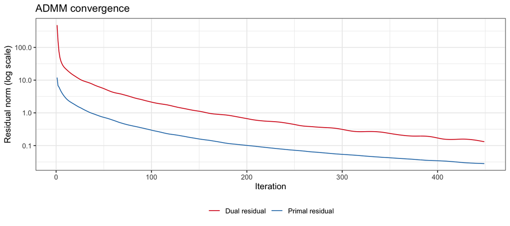

```r
ggplot(solver$history, aes(x = iter)) +
  geom_line(aes(y = r_primal, colour = "Primal residual")) +
  geom_line(aes(y = r_dual,   colour = "Dual residual")) +
  scale_y_log10() +
  scale_colour_manual(
    values = c("Primal residual" = "#2c7bb6", "Dual residual" = "#d7191c"),
    name   = NULL
  ) +
  labs(title = "ADMM convergence",
       x = "Iteration", y = "Residual norm (log scale)") +
  theme_bw() +
  theme(legend.position = "bottom")
```

# 5 Results

## 5.1 Long-format data frame

```r
latent_years <- inp_black$metadata$first_latent_year:inp_black$metadata$last_latent_year

X_long <- as.data.frame(X_hat)
colnames(X_long) <- as.character(latent_years)
X_long$GEOID     <- rownames(X_hat)

X_long <- tidyr::pivot_longer(
  X_long,
  cols      = -GEOID,
  names_to  = "year",
  values_to = "prop_black_hat"
)
X_long$year <- as.integer(X_long$year)
```

## 5.2 Time series: selected tracts

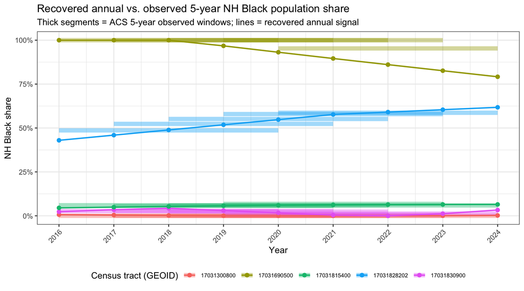

```r
# Observed proportions in long format
Y_long <- as.data.frame(Y_prop)
colnames(Y_long) <- as.character(year_ends)
Y_long$GEOID     <- rownames(Y_prop)

Y_long <- tidyr::pivot_longer(
  Y_long,
  cols      = -GEOID,
  names_to  = "year_end",
  values_to = "prop_obs"
)
Y_long$year_end <- as.integer(Y_long$year_end)

# Select 5 representative tracts spanning the NH Black share distribution
mean_prop  <- rowMeans(Y_prop, na.rm = TRUE)
sel_geoids <- names(sort(mean_prop))[
  round(seq(1, sum(!is.na(mean_prop)), length.out = 5))
]

X_sel <- X_long[X_long$GEOID %in% sel_geoids, ]
Y_sel <- Y_long[Y_long$GEOID %in% sel_geoids, ]

ggplot() +
  geom_segment(
    data = Y_sel,
    aes(x = year_end - 4, xend = year_end,
        y = prop_obs, yend = prop_obs, colour = GEOID),
    linewidth = 2.5, alpha = 0.4
  ) +
  geom_line(
    data = X_sel,
    aes(x = year, y = prop_black_hat, colour = GEOID),
    linewidth = 0.8
  ) +
  geom_point(
    data = X_sel,
    aes(x = year, y = prop_black_hat, colour = GEOID),
    size = 2
  ) +
  scale_y_continuous(labels = scales::percent_format(accuracy = 1)) +
  scale_x_continuous(breaks = latent_years) +
  labs(
    title    = "Recovered annual vs. observed 5-year NH Black population share",
    subtitle = "Thick segments = ACS 5-year observed windows; lines = recovered annual signal",
    x = "Year", y = "NH Black share",
    colour = "Census tract (GEOID)"
  ) +
  theme_bw() +
  theme(legend.position = "bottom",
        axis.text.x     = element_text(angle = 45, hjust = 1),
        legend.text     = element_text(size = 7))
```

## 5.3 Spatial maps: recovered share by year

```r
tracts_sf <- tidycensus::get_acs(
  geography = "tract",
  variables = "B03002_001",
  state     = "IL",
  county    = "Cook",
  year      = 2022,
  survey    = "acs5",
  geometry  = TRUE
) |>
  dplyr::select(GEOID, geometry) |>
  dplyr::distinct(GEOID, .keep_all = TRUE)
```

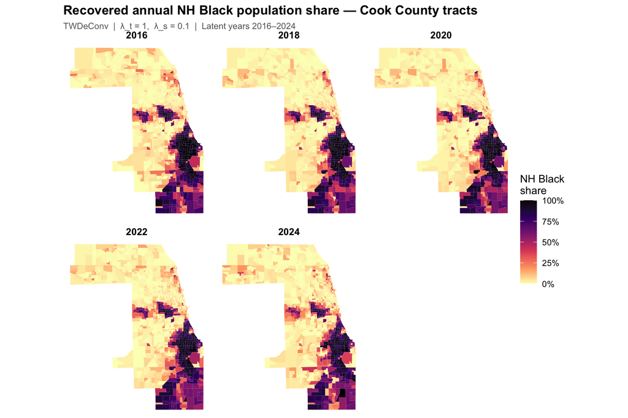

```r
years_to_map <- c(2016, 2018, 2020, 2022, 2024)

map_df <- X_long |>
  dplyr::filter(year %in% years_to_map) |>
  dplyr::left_join(tracts_sf, by = "GEOID") |>
  sf::st_as_sf()

ggplot(map_df) +
  geom_sf(aes(fill = prop_black_hat), colour = NA) +
  facet_wrap(~ year, ncol = 3) +
  scale_fill_viridis_c(
    option   = "magma", direction = -1,
    name     = "NH Black\nshare",
    labels   = scales::percent_format(accuracy = 1),
    na.value = "grey80"
  ) +
  labs(
    title    = "Recovered annual NH Black population share — Cook County tracts",
    subtitle = paste0("TWDeConv  |  \u03bb_t = 1,  \u03bb_s = 0.1  |  Latent years ",
                      min(latent_years), "\u2013", max(latent_years))
  ) +
  theme_void() +
  theme(
    strip.text      = element_text(face = "bold", size = 10),
    legend.position = "right",
    plot.title      = element_text(face = "bold"),
    plot.subtitle   = element_text(colour = "grey40", size = 9)
  )
```

# 6 Validation: Three-Way Comparison with 2020 Decennial Census

## 6.1 Why the Decennial Census works here

Unlike income (which the Decennial does not collect), **racial composition is measured by the Decennial Census** as a full enumeration with no sampling error. The 2020 PL 94-171 redistricting file provides:

| Variable | Description |
| --- | --- |
| `P2_001N` | Total population |
| `P2_006N` | Not Hispanic or Latino: Black or African American alone |

Two caveats apply:

1. **Timing**: the Decennial is a single-day snapshot (April 1, 2020); the deconvolved estimate represents an annual average. In rapidly changing tracts these may differ.
2. **Mode effects**: mail/online survey (ACS) vs. enumerator (Decennial) can produce small differences in self-reported race.

We make **two comparisons** against the Decennial 2020 as ground truth:

- **Comparison A — ACS 2018–2022 (naive)**: the single conventional 5-year window that a researcher would use for “circa 2020” estimates.
- **Comparison B — TWDeConv 2020 (deconvolved)**: the annual signal recovered from five overlapping windows (end years 2020–2024).

## 6.2 Fetch Decennial 2020 tract data

```r
dec_raw <- tidycensus::get_decennial(
  geography = "tract",
  variables = c(total    = "P2_001N",
                black_nh = "P2_006N"),
  state     = "IL",
  county    = "Cook",
  year      = 2020,
  sumfile   = "pl"
)

dec_2020 <- dec_raw |>
  dplyr::select(GEOID, variable, value) |>
  tidyr::pivot_wider(names_from = variable, values_from = value) |>
  dplyr::mutate(
    prop_black_dec = dplyr::if_else(total > 0, black_nh / total, NA_real_)
  )

cat("Decennial tracts:", nrow(dec_2020), "\n")
```

```
## Decennial tracts: 1332
```

```r
cat("Proportion range:", round(range(dec_2020$prop_black_dec, na.rm = TRUE), 3), "\n")
```

```
## Proportion range: 0.001 0.974
```

## 6.3 Fetch ACS 2018–2022 naive estimate

The ACS 2018–2022 5-year estimate (window ending in 2022) is the conventional single-snapshot that most researchers would use for the year 2020.

```r
acs_black_22 <- fetch_acs_vre_data(
  state     = "IL",
  county    = "Cook",
  year_end  = 2022,
  variables = c(black_nh = "B03002_004"),
  geometry  = FALSE,
  vre       = FALSE,
  cache_dir = "~/acs_cache",
  quiet     = TRUE
)

acs_total_22 <- fetch_acs_vre_data(
  state     = "IL",
  county    = "Cook",
  year_end  = 2022,
  variables = c(total = "B03002_001"),
  geometry  = FALSE,
  vre       = FALSE,
  cache_dir = "~/acs_cache",
  quiet     = TRUE
)

g22          <- intersect(rownames(acs_black_22$estimates), rownames(acs_total_22$estimates))
acs_naive_df <- data.frame(
  GEOID          = g22,
  prop_black_acs = acs_black_22$estimates[g22, "black_nh"] /
                   acs_total_22$estimates[g22, "total"],
  stringsAsFactors = FALSE
)

cat("ACS 2018-2022 tracts:", nrow(acs_naive_df), "\n")
```

```
## ACS 2018-2022 tracts: 1332
```

```r
cat("Proportion range:", round(range(acs_naive_df$prop_black_acs, na.rm = TRUE), 3), "\n")
```

```
## Proportion range: 0 1
```

## 6.4 Agreement statistics

```r
twdeconv_2020 <- X_long |>
  dplyr::filter(year == 2020) |>
  dplyr::select(GEOID, prop_black_hat)

# Comparison A: ACS 2018-2022 vs. Decennial 2020
comp_acs <- acs_naive_df |>
  dplyr::inner_join(dec_2020, by = "GEOID") |>
  dplyr::filter(!is.na(prop_black_acs), !is.na(prop_black_dec))

rmse_acs <- sqrt(mean((comp_acs$prop_black_acs - comp_acs$prop_black_dec)^2))
mae_acs  <- mean(abs(comp_acs$prop_black_acs   - comp_acs$prop_black_dec))
bias_acs <- mean(comp_acs$prop_black_acs        - comp_acs$prop_black_dec)
r_acs    <- cor(comp_acs$prop_black_acs, comp_acs$prop_black_dec)

# Comparison B: TWDeConv 2020 vs. Decennial 2020
comp_tw <- twdeconv_2020 |>
  dplyr::inner_join(dec_2020, by = "GEOID") |>
  dplyr::filter(!is.na(prop_black_hat), !is.na(prop_black_dec))

rmse_tw <- sqrt(mean((comp_tw$prop_black_hat - comp_tw$prop_black_dec)^2))
mae_tw  <- mean(abs(comp_tw$prop_black_hat   - comp_tw$prop_black_dec))
bias_tw <- mean(comp_tw$prop_black_hat        - comp_tw$prop_black_dec)
r_tw    <- cor(comp_tw$prop_black_hat, comp_tw$prop_black_dec)

# Summary table
stats_tbl <- data.frame(
  Method           = c("ACS 2018-2022 (naive)", "TWDeConv 2020"),
  Tracts           = c(nrow(comp_acs), nrow(comp_tw)),
  r                = round(c(r_acs,    r_tw),    4),
  `RMSE (pct pts)` = round(c(rmse_acs, rmse_tw) * 100, 2),
  `MAE (pct pts)`  = round(c(mae_acs,  mae_tw)  * 100, 2),
  `Bias (pct pts)` = round(c(bias_acs, bias_tw) * 100, 2),
  check.names      = FALSE
)

knitr::kable(stats_tbl,
             caption = "Agreement with 2020 Decennial Census: NH Black population share")
```

Agreement with 2020 Decennial Census: NH Black population share

| Method | Tracts | r | RMSE (pct pts) | MAE (pct pts) | Bias (pct pts) |
| --- | --- | --- | --- | --- | --- |
| ACS 2018-2022 (naive) | 1328 | 0.9903 | 4.86 | 3.16 | -0.29 |
| TWDeConv 2020 | 1330 | 0.9887 | 5.25 | 3.23 | -0.23 |

## 6.5 Scatter plots: ACS 2018–2022 and TWDeConv 2020 vs. Decennial 2020

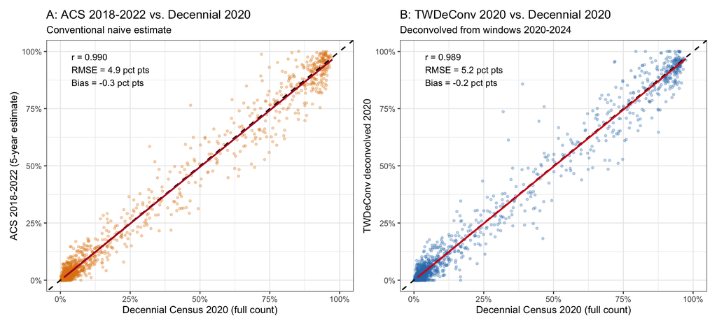

```r
p_acs <- ggplot(comp_acs, aes(x = prop_black_dec, y = prop_black_acs)) +
  geom_point(alpha = 0.3, size = 1, colour = "#e08214") +
  geom_abline(slope = 1, intercept = 0, linetype = "dashed", linewidth = 0.7) +
  geom_smooth(method = "lm", colour = "#b2182b", se = FALSE, linewidth = 0.9) +
  scale_x_continuous(labels = scales::percent_format(accuracy = 1), limits = c(0, 1)) +
  scale_y_continuous(labels = scales::percent_format(accuracy = 1), limits = c(0, 1)) +
  annotate("text", x = 0.04, y = 0.92, hjust = 0, size = 3.5,
           label = sprintf("r = %.3f\nRMSE = %.1f pct pts\nBias = %+.1f pct pts",
                           r_acs, rmse_acs * 100, bias_acs * 100)) +
  labs(title = "A: ACS 2018-2022 vs. Decennial 2020",
       subtitle = "Conventional naive estimate",
       x = "Decennial Census 2020 (full count)",
       y = "ACS 2018-2022 (5-year estimate)") +
  theme_bw()

p_tw <- ggplot(comp_tw, aes(x = prop_black_dec, y = prop_black_hat)) +
  geom_point(alpha = 0.3, size = 1, colour = "#2c7bb6") +
  geom_abline(slope = 1, intercept = 0, linetype = "dashed", linewidth = 0.7) +
  geom_smooth(method = "lm", colour = "#d7191c", se = FALSE, linewidth = 0.9) +
  scale_x_continuous(labels = scales::percent_format(accuracy = 1), limits = c(0, 1)) +
  scale_y_continuous(labels = scales::percent_format(accuracy = 1), limits = c(0, 1)) +
  annotate("text", x = 0.04, y = 0.92, hjust = 0, size = 3.5,
           label = sprintf("r = %.3f\nRMSE = %.1f pct pts\nBias = %+.1f pct pts",
                           r_tw, rmse_tw * 100, bias_tw * 100)) +
  labs(title = "B: TWDeConv 2020 vs. Decennial 2020",
       subtitle = "Deconvolved from windows 2020-2024",
       x = "Decennial Census 2020 (full count)",
       y = "TWDeConv deconvolved 2020") +
  theme_bw()

patchwork::wrap_plots(p_acs, p_tw, nrow = 1)
```

## 6.6 Three-way spatial maps

[figure not shown]

```r
map_threeway <- dec_2020 |>
  dplyr::select(GEOID, prop_black_dec) |>
  dplyr::left_join(acs_naive_df, by = "GEOID") |>
  dplyr::left_join(twdeconv_2020, by = "GEOID") |>
  dplyr::left_join(tracts_sf, by = "GEOID") |>
  sf::st_as_sf() |>
  tidyr::pivot_longer(
    cols      = c(prop_black_dec, prop_black_acs, prop_black_hat),
    names_to  = "source",
    values_to = "prop_black"
  ) |>
  dplyr::mutate(source = factor(
    dplyr::recode(source,
      prop_black_dec = "Decennial 2020\n(full count)",
      prop_black_acs = "ACS 2018-2022\n(5-year naive)",
      prop_black_hat = "TWDeConv 2020\n(deconvolved)"
    ),
    levels = c("Decennial 2020\n(full count)",
               "ACS 2018-2022\n(5-year naive)",
               "TWDeConv 2020\n(deconvolved)")
  ))

ggplot(map_threeway) +
  geom_sf(aes(fill = prop_black), colour = NA) +
  facet_wrap(~ source, nrow = 1) +
  scale_fill_viridis_c(
    option   = "grey", direction = -1,
    name     = "NH Black\nshare",
    labels   = scales::percent_format(accuracy = 1),
    na.value = "grey80"
  ) +
  labs(
    title    = "NH Black population share: three-way comparison",
    subtitle = "Cook County Census tracts  |  Reference year: 2020"
  ) +
  theme_void() +
  theme(
    strip.text      = element_text(face = "bold", size = 9),
    legend.position = "right",
    plot.title      = element_text(face = "bold"),
    plot.subtitle   = element_text(colour = "grey40", size = 9)
  )
```

## 6.7 Residual maps: ACS and TWDeConv vs. Decennial

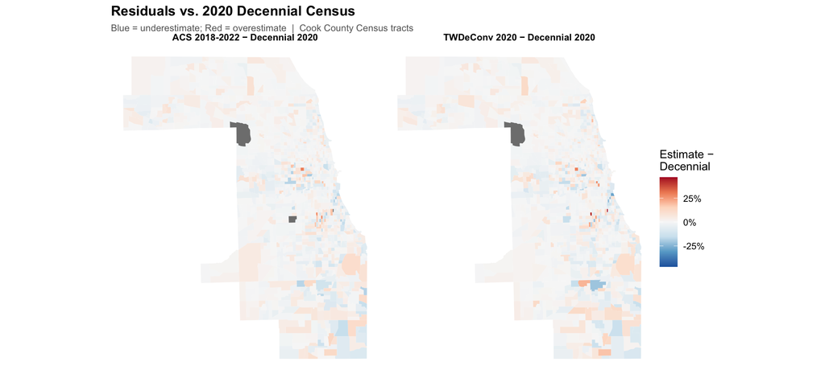

```r
map_resid_long <- dec_2020 |>
  dplyr::select(GEOID, prop_black_dec) |>
  dplyr::left_join(acs_naive_df, by = "GEOID") |>
  dplyr::left_join(twdeconv_2020, by = "GEOID") |>
  dplyr::mutate(
    resid_acs = prop_black_acs - prop_black_dec,
    resid_tw  = prop_black_hat - prop_black_dec
  ) |>
  dplyr::left_join(tracts_sf, by = "GEOID") |>
  sf::st_as_sf() |>
  tidyr::pivot_longer(
    cols      = c(resid_acs, resid_tw),
    names_to  = "method",
    values_to = "residual"
  ) |>
  dplyr::mutate(method = factor(
    dplyr::recode(method,
      resid_acs = "ACS 2018-2022 \u2212 Decennial 2020",
      resid_tw  = "TWDeConv 2020 \u2212 Decennial 2020"
    ),
    levels = c("ACS 2018-2022 \u2212 Decennial 2020",
               "TWDeConv 2020 \u2212 Decennial 2020")
  ))

lim <- max(abs(map_resid_long$residual), na.rm = TRUE)

ggplot(map_resid_long) +
  geom_sf(aes(fill = residual), colour = NA) +
  facet_wrap(~ method, nrow = 1) +
  scale_fill_distiller(
    palette  = "RdBu",
    limits   = c(-lim, lim),
    name     = "Estimate \u2212\nDecennial",
    labels   = scales::percent_format(accuracy = 1)
  ) +
  labs(
    title    = "Residuals vs. 2020 Decennial Census",
    subtitle = "Blue = underestimate; Red = overestimate  |  Cook County Census tracts"
  ) +
  theme_void() +
  theme(
    strip.text      = element_text(face = "bold", size = 9),
    legend.position = "right",
    plot.title      = element_text(face = "bold"),
    plot.subtitle   = element_text(colour = "grey40", size = 9)
  )
```

# 7 Precision Comparison — TWDeConv vs. ACS 2018–2022

We now quantify the uncertainty of the TWDeConv point estimates via a **parametric bootstrap** and compare those margins of error (MOE) against the conventional ACS 2018–2022 single-window MOE.

The bootstrap perturbs the observed proportion matrix $Y$ by its ACS sampling SEs and re-solves the deconvolution $B$ times, reusing the Cholesky factorisation of the system matrix — so only the cheap data term $M^\top W y$ is updated per replicate.

## 7.1 Bootstrap SE

```r
boot <- bootstrap_deconv_se(
  Y          = Y_prop,
  SE_Y       = SE_prop,
  M          = inp_black$M,
  W          = W_prop,
  D          = inp_black$D,
  Ls         = inp_black$Ls,
  lambda_t   = 1,
  lambda_s   = 0.1,
  rho        = 1.0,
  max_iter   = 5000,
  B          = 100L,
  conf_level = 0.90,
  clip       = c(0, 1),
  seed       = 42L,
  verbose    = TRUE
)
print(boot)
```

```
## DeconvBootstrap
##   Dimensions : 1332 cells x 9 years
##   Replicates : B = 100
##   Conf level : 90%
##   Median MOE : 0.0819
```

## 7.2 ACS 2018–2022 MOE (single-window baseline)

```r
N_22   <- acs_total_22$estimates[g22, "total"]
p_22   <- acs_naive_df$prop_black_acs
se_x22 <- acs_black_22$se[g22, "black_nh"]
se_n22 <- acs_total_22$se[g22, "total"]

disc22    <- se_x22^2 - p_22^2 * se_n22^2
SE_acs22  <- ifelse(
  !is.na(disc22) & disc22 >= 0,
  sqrt(disc22) / N_22,
  sqrt(se_x22^2 + p_22^2 * se_n22^2) / N_22
)
MOE_acs22 <- 1.645 * SE_acs22   # 90 % MOE to match boot$conf_level

cat("ACS 2018-2022 MOE  — median:", round(median(MOE_acs22, na.rm=TRUE), 4),
    "  mean:", round(mean(MOE_acs22, na.rm=TRUE), 4), "\n")
```

```
## ACS 2018-2022 MOE  — median: 0.0396   mean: 0.0554
```

## 7.3 MOE comparison summary

```r
moe_2020_col <- which(latent_years == 2020)
moe_tw_2020  <- boot$MOE[, moe_2020_col]

# Align tracts by GEOID
moe_df <- data.frame(
  GEOID   = rownames(boot$MOE),
  moe_tw  = moe_tw_2020,
  moe_acs = MOE_acs22[match(rownames(boot$MOE), g22)],
  stringsAsFactors = FALSE
)
moe_df <- moe_df[!is.na(moe_df$moe_tw) & !is.na(moe_df$moe_acs), ]
moe_df$ratio <- moe_df$moe_tw / moe_df$moe_acs

pct_narrower <- mean(moe_df$ratio < 1, na.rm = TRUE) * 100

summary_tbl <- data.frame(
  Method              = c("TWDeConv 2020 (bootstrap)", "ACS 2018-2022 (single window)"),
  `Median MOE`        = round(c(median(moe_df$moe_tw),  median(moe_df$moe_acs)),  4),
  `Mean MOE`          = round(c(mean(moe_df$moe_tw),    mean(moe_df$moe_acs)),    4),
  `Max MOE`           = round(c(max(moe_df$moe_tw),     max(moe_df$moe_acs)),     4),
  check.names = FALSE
)

knitr::kable(summary_tbl,
             caption = paste0("90% MOE comparison: TWDeConv 2020 vs. ACS 2018-2022  |  ",
                              round(pct_narrower, 1), "% of tracts have narrower TWDeConv MOE"))
```

90% MOE comparison: TWDeConv 2020 vs. ACS 2018-2022 | 50.3% of tracts have narrower TWDeConv MOE

| Method | Median MOE | Mean MOE | Max MOE |
| --- | --- | --- | --- |
| TWDeConv 2020 (bootstrap) | 0.0330 | 0.0489 | 0.2173 |
| ACS 2018-2022 (single window) | 0.0396 | 0.0554 | 0.4406 |

## 7.4 Scatter: TWDeConv 2020 MOE vs. ACS 2018–2022 MOE

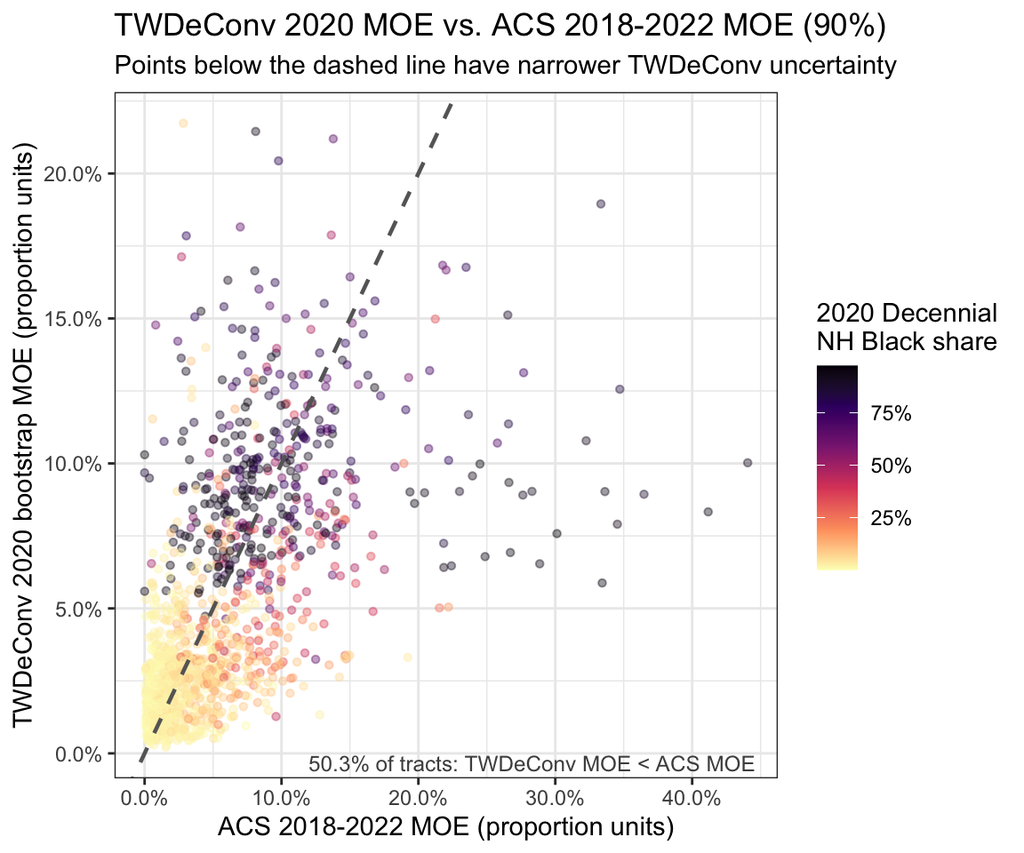

```r
# Colour points by decennial NH Black share to see if high-share tracts benefit more
dec_share_vec <- dec_2020$prop_black_dec[match(moe_df$GEOID, dec_2020$GEOID)]

ggplot(moe_df, aes(x = moe_acs, y = moe_tw, colour = dec_share_vec)) +
  geom_point(alpha = 0.4, size = 1.2) +
  geom_abline(slope = 1, intercept = 0, linetype = "dashed", linewidth = 0.8,
              colour = "grey40") +
  scale_colour_viridis_c(
    option = "magma", direction = -1,
    name   = "2020 Decennial\nNH Black share",
    labels = scales::percent_format(accuracy = 1),
    na.value = "grey70"
  ) +
  scale_x_continuous(labels = scales::percent_format(accuracy = 0.1)) +
  scale_y_continuous(labels = scales::percent_format(accuracy = 0.1)) +
  annotate("text", x = Inf, y = -Inf, hjust = 1.05, vjust = -0.5,
           size = 3.2, colour = "grey30",
           label = sprintf("%.1f%% of tracts: TWDeConv MOE < ACS MOE", pct_narrower)) +
  labs(
    title    = "TWDeConv 2020 MOE vs. ACS 2018-2022 MOE (90%)",
    subtitle = "Points below the dashed line have narrower TWDeConv uncertainty",
    x = "ACS 2018-2022 MOE (proportion units)",
    y = "TWDeConv 2020 bootstrap MOE (proportion units)"
  ) +
  theme_bw() +
  theme(legend.position = "right")
```

## 7.5 Map: MOE ratio (TWDeConv / ACS)

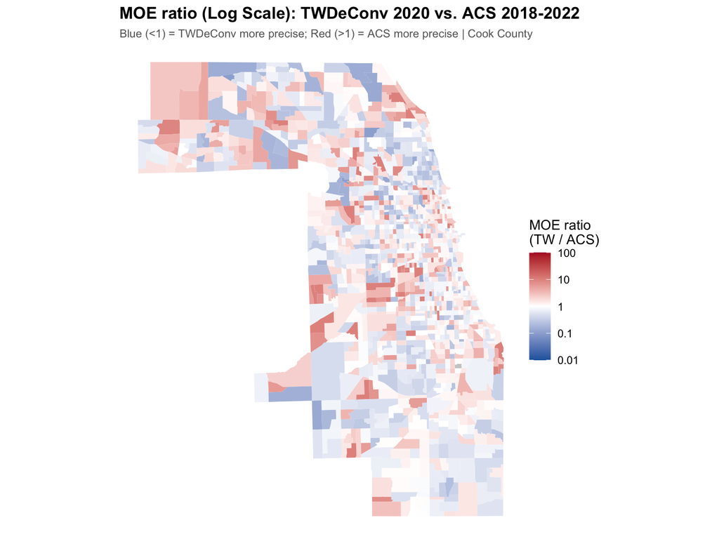

```r
# 1. Prepare data with log2 transformation
moe_ratio_sf <- moe_df |>
  dplyr::mutate(
    # Ensure ratio is finite
    ratio = dplyr::if_else(is.finite(ratio) & ratio > 0, ratio, NA_real_),
    # Take log2 of the ratio for symmetric divergence
    log_ratio = log2(ratio),
    # Clamp values to a reasonable range (e.g., log2(0.1) to log2(10))
    log_ratio = pmin(pmax(log_ratio, log2(0.1)), log2(10))
  ) |>
  dplyr::left_join(tracts_sf, by = "GEOID") |>
  sf::st_as_sf()

# 2. Define breaks for the legend (original ratio values)
# These are the values people understand intuitively
breaks_ratio <- c(0.01, 0.1, 1, 10, 100)
# Map those breaks to the log2 scale we are actually plotting
breaks_log <- log2(breaks_ratio)

# 3. Plot
ggplot(moe_ratio_sf) +
  geom_sf(aes(fill = log_ratio), colour = NA) +
  scale_fill_gradient2(
    low      = "#2166AC",  # Blue
    mid      = "white",    # Neutral
    high     = "#B2182B",  # Red
    midpoint = 0,          # log2(1) = 0
    limits   = c(log2(0.01), log2(100)),
    breaks   = breaks_log,
    labels   = breaks_ratio, # Display the original ratios on the legend
    name     = "MOE ratio\n(TW / ACS)",
    na.value = "grey80"
  ) +
  labs(
    title    = "MOE ratio (Log Scale): TWDeConv 2020 vs. ACS 2018-2022",
    subtitle = "Blue (<1) = TWDeConv more precise; Red (>1) = ACS more precise | Cook County"
  ) +
  theme_void() +
  theme(
    legend.position = "right",
    plot.title      = element_text(face = "bold"),
    plot.subtitle   = element_text(colour = "grey40", size = 9)
  )
```